# Replication Assignment 1 - Candy Rankings

Yifang Hao

Due October 13, 2021 by 11:59 PM CDT

# Instructions and Setup

- Answer all the following questions in this notebook either following the `# ANSWER:` or `**ANSWER**` prompts. For mathematical equations, replace the text between the `$$` with the appropriate formulas.
- Use complete sentences, proof-read, and show all necessary work. After you finish, make sure to re-run all the R-chunks before clicking “Preview” and submitting. You can do this by clicking the dropdown menu that says “Run” in the toolbar above and then selecting “Run All”. There is a non-zero probability that Dr. Selby will download the Rmd file and try to run it on her computer. If it does not run from top to bottom, she will not accept the assignment.
- Submit your .nb.html file on Canvas by the date and time listed above.
- Lastly, post all code used to load necessary libraries in the following R-chunk.

```r
# ANSWER:
```

# Questions

## 1. *Background*

Go to https://fivethirtyeight.com/features/the-ultimate-halloween-candy-power-ranking/ and watch the video and read the article.

Discuss the research question addressed in this article:

**ANSWER:** The research question in this article is “What Halloween candy people most prefer?”

## 2. *Data*

Load the data set `candy_rankings` from the package `fivethirtyeight`.

```r
library("fivethirtyeight")
data(candy_rankings)
```

## 3. *Summary Table*

Create a well-formatted and informative summary statistics table. Interpret the mean of two of your variables.

```r
library(stargazer)
stargazer(candy_rankings, type = "text", title = "Table 1: Summary Statistics Table")
```

```
Table 1: Summary Statistics Table
===================================================================
Statistic        N   Mean  St. Dev.  Min   Pctl(25) Pctl(75)  Max
-------------------------------------------------------------------
chocolate        85 0.435   0.499     0       0        1       1
fruity           85 0.447   0.500     0       0        1       1
caramel          85 0.165   0.373     0       0        0       1
peanutyalmondy   85 0.165   0.373     0       0        0       1
nougat           85 0.082   0.277     0       0        0       1
crispedricewafer 85 0.082   0.277     0       0        0       1
hard             85 0.176   0.383     0       0        0       1
bar              85 0.247   0.434     0       0        0       1
pluribus         85 0.518   0.503     0       0        1       1
sugarpercent     85 0.479   0.283   0.011   0.220    0.732   0.988
pricepercent     85 0.469   0.286   0.011   0.255    0.651   0.976
winpercent       85 50.317  14.714  22.445  39.141   59.864  84.180
-------------------------------------------------------------------
```

**ANSWER:** The mean of variable “chocolate” means there are 43.5% of the candies contain chocolate in this data set, and the mean of variable “fruity” means there are 44.7% of the candies are fruit flavored in this data set.

## 4. *Summary Graphs*

Create two high-quality graphs/figures that illustrate the data in a way that is informative for the reader. Explain, in text, what these figures illustrate.

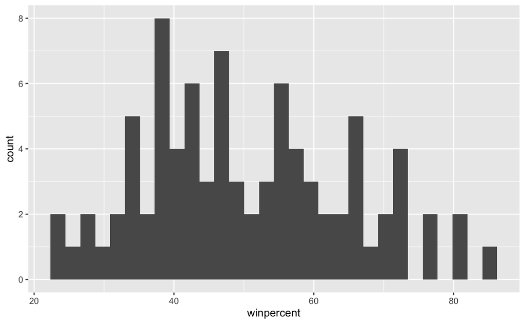

```r
library("ggplot2")
ggplot(candy_rankings, aes(winpercent)) + geom_histogram()
```

**ANSWER** The variable “winpercent” records the percentage of people who prefer this candy over another randomly chosen candy from the data set. According to the histogram above, we can see that the distribution of rankings looks pretty symmetrical, and seems to center on about 45%.

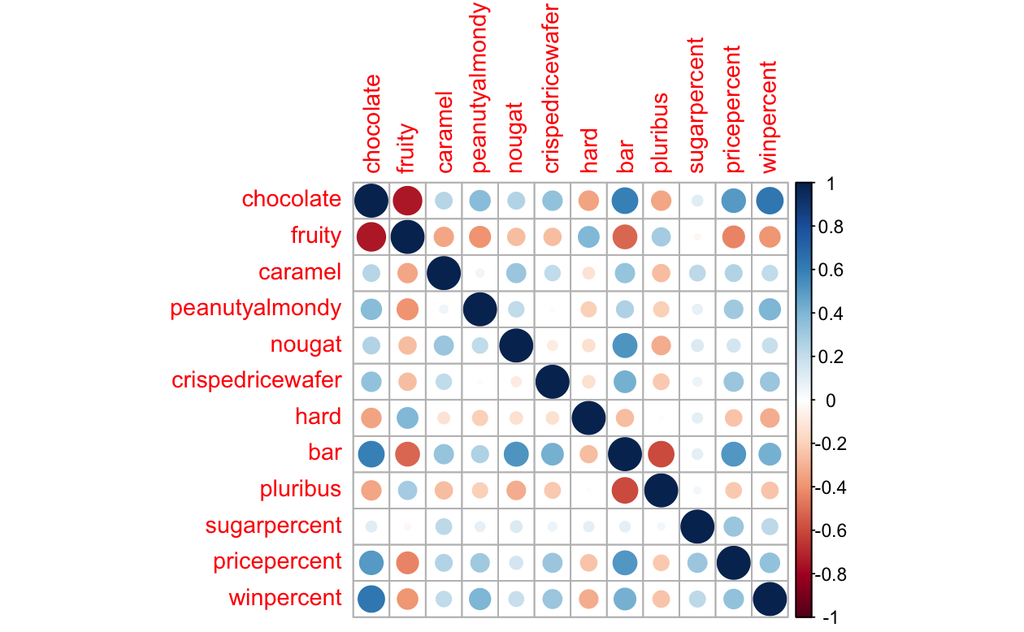

```r
library(corrplot)
cor(candy_rankings[, 2:13]) %>%
corrplot()
```

**ANSWER:** By using the ‘corrplot’ package to plot the correlation matrix, we can see that it looks like a candy contains chocolate is least likely to contain fruit; a candy contains chocolate is more likely to be a bar candy than a hard candy; and it looks like a candy contains chocolate is more likely to win.

## 5. *Empirical Model*

Write a multiple linear regression empirical model that was was estimated in the article. Intepret the coefficients in the context of the problem. What would it mean for a coefficient to be statistically significant? What is the assumptions made when using this linear model?

$$winpercent = \beta_0 + \beta_1chocolate + \beta_2fruity+ \beta_3caramel + \beta_4 peanutyalmondy + \beta_5nougat + \beta_6crispedricewafer + \beta_6hard + \beta_7bar + \beta_8pluribus +\varepsilon$$

**ANSWER:** In the article, the authors created a linear model of ‘winpercent’ using all the other variables (except competitorname, sugarpercent, pricepercent). We can see the coefficients between ‘winpercent’ and some other variables shown below. The coefficients mean that if a hypothetical candy had chocolate in it, we would expect its win percentage to rise by about 19.91 points; if it’s fruity, we would expect its win percentage to rise by about 10.27 points; if it has peanuts, peanut butter, or almond, we would expect its win percentage to rise by about by 10.14 points; if it has wafers or crisped rice, we would expect its win percentage to rise by about by 8.99 points; if it has caramel, we would expect its win percentage to rise by about by 3.38 points; if it has nougat, we would expect its win percentage to rise by about by 2.42 points. On the other hand, a candy being hard — like a lollipop or jawbreaker — actually knocks about 4.87 points off its win percentage. Whether it’s in bar form or a bunch of little candies makes no major difference (only expect its win percentage to drop by 0.72 points and 0.16 points respectively). A coefficient would be considered to be statistically significant when its p-value equal to or lower than 5%, and a coefficient is statistically significant means that changes in the predictor are associated with changes in the response. When using this linear model, we assume that 1)there is a linear relationship between the dependent variable ‘winprecent’ and each of the independent variables; 2)the independent variables are not highly correlated with each other; 3)the amount of error in the residuals is similar at each point of the linear model;4) the observations should be independent of one another.

```r
win_model <- lm(winpercent ~ chocolate + fruity + caramel + peanutyalmondy + nougat + crispedricewafer + hard + bar +pluribus, data = candy_rankings)
win_model
```

```
Call:
lm(formula = winpercent ~ chocolate + fruity + caramel + peanutyalmondy +
    nougat + crispedricewafer + hard + bar + pluribus, data = candy_rankings)

Coefficients:
         (Intercept)         chocolateTRUE            fruityTRUE           caramelTRUE    peanutyalmondyTRUE
             35.0155               19.9058               10.2677                3.3843               10.1410
          nougatTRUE  crispedricewaferTRUE              hardTRUE               barTRUE          pluribusTRUE
              2.4163                8.9915               -4.8726               -0.7220               -0.1599
```

## 6. *Results*

Replicate the regression table in the article. Display results in a nicely-formatted table.

```r
summary(win_model)
```

```
Call:
lm(formula = winpercent ~ chocolate + fruity + caramel + peanutyalmondy +
    nougat + crispedricewafer + hard + bar + pluribus, data = candy_rankings)

Residuals:
     Min       1Q   Median       3Q      Max
-22.6779  -5.6765   0.3966   7.0583  21.9144

Coefficients:
                     Estimate Std. Error t value Pr(>|t|)
(Intercept)           35.0155     4.0781   8.586 9.13e-13 ***
chocolateTRUE         19.9058     3.8975   5.107 2.41e-06 ***
fruityTRUE            10.2677     3.7887   2.710  0.00833 **
caramelTRUE            3.3843     3.6034   0.939  0.35065
peanutyalmondyTRUE    10.1410     3.5949   2.821  0.00612 **
nougatTRUE             2.4163     5.6897   0.425  0.67229
crispedricewaferTRUE   8.9915     5.3279   1.688  0.09564 .
hardTRUE              -4.8726     3.4394  -1.417  0.16072
barTRUE               -0.7220     4.8707  -0.148  0.88256
pluribusTRUE          -0.1599     3.0115  -0.053  0.95779
---
Signif. codes:  0 ‘***’ 0.001 ‘**’ 0.01 ‘*’ 0.05 ‘.’ 0.1 ‘ ’ 1

Residual standard error: 10.85 on 75 degrees of freedom
Multiple R-squared:  0.5148,    Adjusted R-squared:  0.4566
F-statistic: 8.842 on 9 and 75 DF,  p-value: 6.052e-09
```

```r
stargazer(win_model, type = "text", title = "Table 2: Regression of winpercent chocolate fruity caramel peanutyalmondy nougat crispedricewafer hard bar pluribus ")
```

```
Table 2: Regression of winpercent chocolate fruity caramel peanutyalmondy nougat crispedricewafer hard bar pluribus
===============================================
                        Dependent variable:
                    ---------------------------
                            winpercent
-----------------------------------------------
chocolate                    19.906***
                              (3.897)

fruity                       10.268***
                              (3.789)

caramel                        3.384
                              (3.603)

peanutyalmondy               10.141***
                              (3.595)

nougat                         2.416
                              (5.690)

crispedricewafer              8.992*
                              (5.328)

hard                          -4.873
                              (3.439)

bar                           -0.722
                              (4.871)

pluribus                      -0.160
                              (3.012)

Constant                     35.015***
                              (4.078)

-----------------------------------------------
Observations                    85
R2                             0.515
Adjusted R2                    0.457
Residual Std. Error      10.847 (df = 75)
F Statistic            8.842*** (df = 9; 75)
===============================================
Note:               *p<0.1; **p<0.05; ***p<0.01
```

## 7. *Discussion*

Interpret your results from question 6. Did the model explain much of the variation in the dependent variable? Do you feel like anything may have been omitted from the regression that should have been included?

```r
win_model_2 <- lm(winpercent ~ . -competitorname, data = candy_rankings)
win_model_2
```

```
Call:
lm(formula = winpercent ~ . - competitorname, data = candy_rankings)

Coefficients:
         (Intercept)         chocolateTRUE            fruityTRUE           caramelTRUE    peanutyalmondyTRUE
             34.5340               19.7481                9.4223                2.2245               10.0707
          nougatTRUE  crispedricewaferTRUE              hardTRUE               barTRUE          pluribusTRUE
              0.8043                8.9190               -6.1653                0.4415               -0.8545
        sugarpercent          pricepercent
              9.0868               -5.9284
```

```r
stargazer(win_model_2, type = "text")
```

```
===============================================
                        Dependent variable:
                    ---------------------------
                            winpercent
-----------------------------------------------
chocolate                    19.748***
                              (3.899)

fruity                        9.422**
                              (3.763)

caramel                        2.224
                              (3.657)

peanutyalmondy               10.071***
                              (3.616)

nougat                         0.804
                              (5.716)

crispedricewafer              8.919*
                              (5.268)

hard                          -6.165*
                              (3.455)

bar                            0.442
                              (5.061)

pluribus                      -0.854
                              (3.040)

sugarpercent                  9.087*
                              (4.659)

pricepercent                  -5.928
                              (5.513)

Constant                     34.534***
                              (4.320)

-----------------------------------------------
Observations                    85
R2                             0.540
Adjusted R2                    0.471
Residual Std. Error      10.703 (df = 73)
F Statistic           7.797*** (df = 11; 73)
===============================================
Note:               *p<0.1; **p<0.05; ***p<0.01
```